# R Iris Dataset

2015-01-12T00:00:00+08:00

## Iris DataSet

Iris DataSet The data set contains 3 classes of 50 instances each, where each class refers to a type of iris plant. One class is linearly separable from the other 2; the latter are NOT linearly separable from each other.

Predicted attribute: class of iris plant. http://archive.ics.uci.edu/ml/datasets/Iris

```r
data(iris)
head(iris)
```

```
##   Sepal.Length Sepal.Width Petal.Length Petal.Width Species
## 1          5.1         3.5          1.4         0.2  setosa
## 2          4.9         3.0          1.4         0.2  setosa
## 3          4.7         3.2          1.3         0.2  setosa
## 4          4.6         3.1          1.5         0.2  setosa
## 5          5.0         3.6          1.4         0.2  setosa
## 6          5.4         3.9          1.7         0.4  setosa
```

```r
summary(iris)
```

```
##   Sepal.Length    Sepal.Width     Petal.Length    Petal.Width
##  Min.   :4.300   Min.   :2.000   Min.   :1.000   Min.   :0.100
##  1st Qu.:5.100   1st Qu.:2.800   1st Qu.:1.600   1st Qu.:0.300
##  Median :5.800   Median :3.000   Median :4.350   Median :1.300
##  Mean   :5.843   Mean   :3.057   Mean   :3.758   Mean   :1.199
##  3rd Qu.:6.400   3rd Qu.:3.300   3rd Qu.:5.100   3rd Qu.:1.800
##  Max.   :7.900   Max.   :4.400   Max.   :6.900   Max.   :2.500
##        Species
##  setosa    :50
##  versicolor:50
##  virginica :50
##
##
##
```

```r
str(iris)
```

```
## 'data.frame':    150 obs. of  5 variables:
##  $ Sepal.Length: num  5.1 4.9 4.7 4.6 5 5.4 4.6 5 4.4 4.9 ...
##  $ Sepal.Width : num  3.5 3 3.2 3.1 3.6 3.9 3.4 3.4 2.9 3.1 ...
##  $ Petal.Length: num  1.4 1.4 1.3 1.5 1.4 1.7 1.4 1.5 1.4 1.5 ...
##  $ Petal.Width : num  0.2 0.2 0.2 0.2 0.2 0.4 0.3 0.2 0.2 0.1 ...
##  $ Species     : Factor w/ 3 levels "setosa","versicolor",..: 1 1 1 1 1 1 1 1 1 1 ...
```

## Including Plots

### Scatter Plot

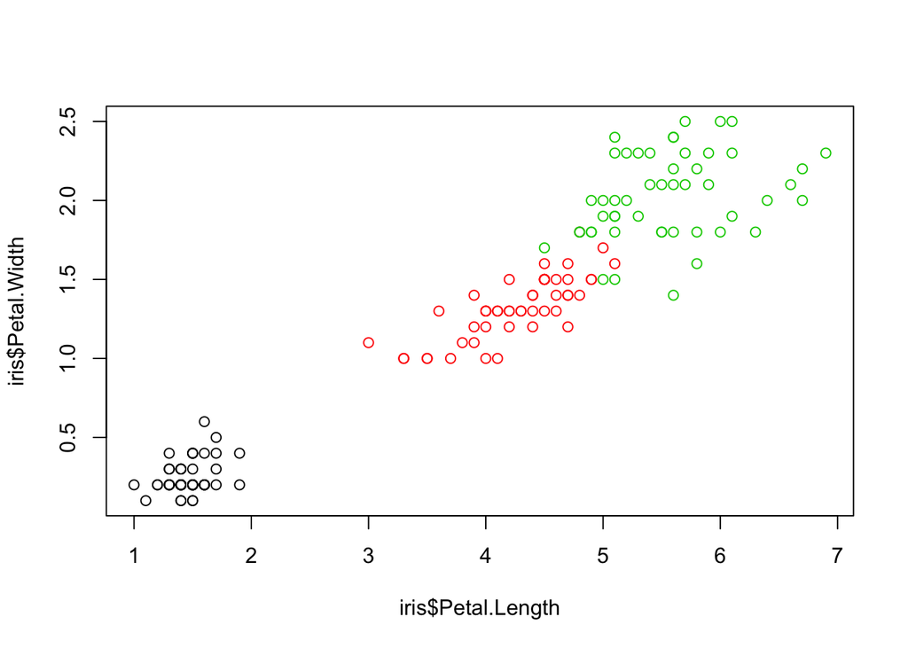

```r
plot(x=iris$Petal.Length, y=iris$Petal.Width, col=iris$Species)
```

We could use the pch argument (plot character) for specify the marking of Species. pch=21 is for filled circles, pch=22 for filled squares, pch=23 for filled diamonds, pch=24 or pch=25 for up/down triangles.

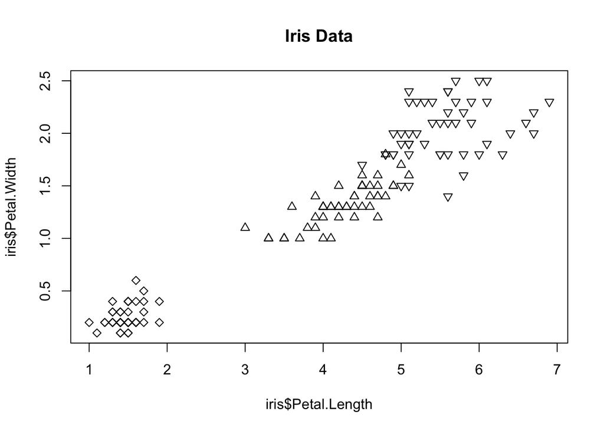

```r
plot(iris$Petal.Length, iris$Petal.Width, pch=c(23,24,25)[unclass(iris$Species)], main="Iris Data")
```

or we can add color to them

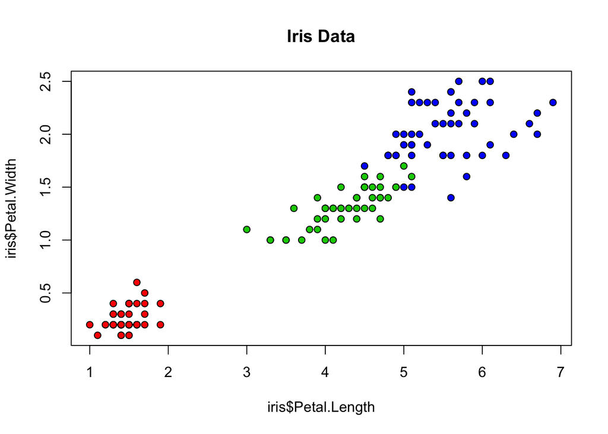

```r
plot(iris$Petal.Length, iris$Petal.Width,pch=21, bg=c("red","green3","blue")[unclass(iris$Species)], main="Iris Data")
```

#### Scatter Plot Matrix

This shows the possible two-dimensional projections of multidimensional data

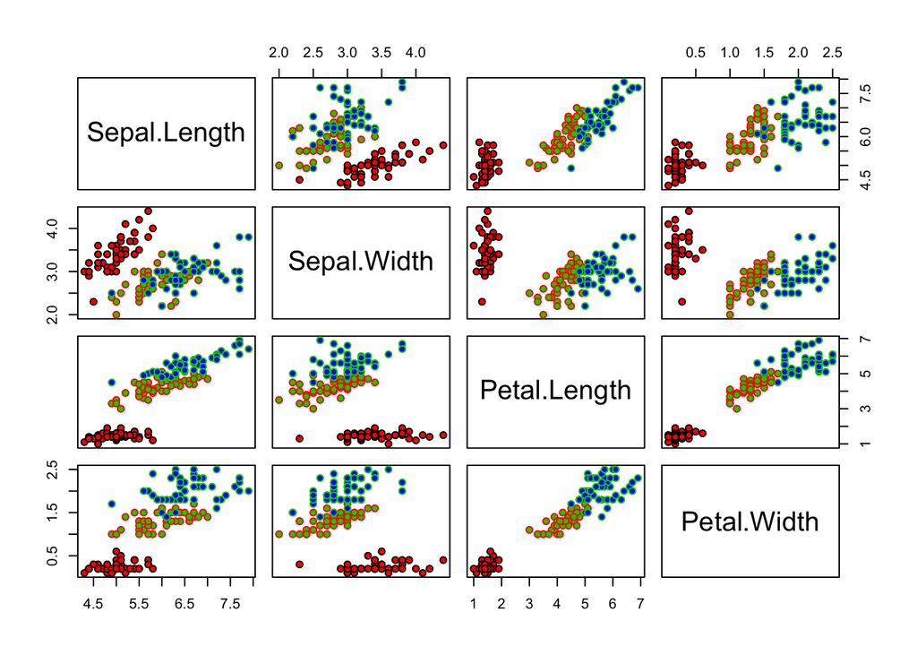

```r
pairs(iris[1:4], col=iris$Species, pch = 21, bg = c("red", "green3", "blue")[unclass(iris$Species)])
```

From the plot the Petal.Length and Petal.Width can be best used for classifying the Species.

This shows the possible two-dimensional projections of multidimensional data. We can print the correlation coeff and p value in the top panel.

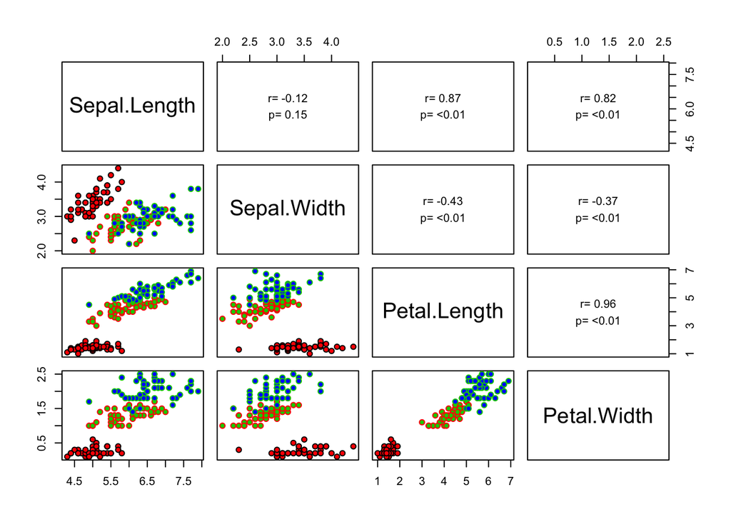

```r
panel.cor <- function(x, y, digits = 2, cex.cor, ...)
{
  usr <- par("usr"); on.exit(par(usr))
  par(usr = c(0, 1, 0, 1))
  # correlation coefficient
  r <- cor(x, y)
  txt <- format(c(r, 0.123456789), digits = digits)[1]
  txt <- paste("r= ", txt, sep = "")
  text(0.5, 0.6, txt)

  # p-value calculation
  p <- cor.test(x, y)$p.value
  txt2 <- format(c(p, 0.123456789), digits = digits)[1]
  txt2 <- paste("p= ", txt2, sep = "")
  if(p<0.01) txt2 <- paste("p= ", "<0.01", sep = "")
  text(0.5, 0.4, txt2)
}

pairs(iris[1:4], col=iris$Species, pch = 21, bg = c("red", "green3", "blue")[unclass(iris$Species)],
      upper.panel=panel.cor)
```

## Using SVM for Classifying the Species

```r
library("e1071")
index <- 1:nrow(iris)
testindex <- sample(index, trunc(length(index)/4))
testset <- iris[testindex,]
trainset <- iris[-testindex,]

svm_model <- svm(Species ~ ., data=trainset)
summary(svm_model)
```

```
##
## Call:
## svm(formula = Species ~ ., data = trainset)
##
##
## Parameters:
##    SVM-Type:  C-classification
##  SVM-Kernel:  radial
##        cost:  1
##       gamma:  0.25
##
## Number of Support Vectors:  43
##
##  ( 9 17 17 )
##
##
## Number of Classes:  3
##
## Levels:
##  setosa versicolor virginica
```

Predict the testdata with model

```r
prediction <- predict(svm_model,testset[,-5])
tab <- table(pred = prediction, true = testset[,5])
tab
```

```
##             true
## pred         setosa versicolor virginica
##   setosa         13          0         0
##   versicolor      0          9         1
##   virginica       0          2        12
```

Tuning SVM for best cost and gamma

```r
svm_tune <- tune.svm(Species ~ ., data=trainset,
              kernel="radial", cost=10^(-1:2), gamma=c(.5,1,2))

print(svm_tune)
```

```
##
## Parameter tuning of 'svm':
##
## - sampling method: 10-fold cross validation
##
## - best parameters:
##  gamma cost
##    0.5    1
##
## - best performance: 0.03560606
```

Run SVM after tuning

```r
svm_model_after_tune <- svm(Species ~ ., data=iris, kernel="radial", cost=1, gamma=0.5)
summary(svm_model_after_tune)
```

```
##
## Call:
## svm(formula = Species ~ ., data = iris, kernel = "radial", cost = 1,
##     gamma = 0.5)
##
##
## Parameters:
##    SVM-Type:  C-classification
##  SVM-Kernel:  radial
##        cost:  1
##       gamma:  0.5
##
## Number of Support Vectors:  59
##
##  ( 11 23 25 )
##
##
## Number of Classes:  3
##
## Levels:
##  setosa versicolor virginica
```

Predict the testdata with model

```r
prediction <- predict(svm_model_after_tune,testset[,-5])
tab <- table(pred = prediction, true = testset[,5])
tab
```

```
##             true
## pred         setosa versicolor virginica
##   setosa         13          0         0
##   versicolor      0          9         0
##   virginica       0          2        13
```

## K Means clustering

```r
set.seed(20)
irisCluster <- kmeans(iris[, 3:4], 3, nstart = 20)
irisCluster
```

```
## K-means clustering with 3 clusters of sizes 50, 52, 48
##
## Cluster means:
##   Petal.Length Petal.Width
## 1     1.462000    0.246000
## 2     4.269231    1.342308
## 3     5.595833    2.037500
##
## Clustering vector:
##   [1] 1 1 1 1 1 1 1 1 1 1 1 1 1 1 1 1 1 1 1 1 1 1 1 1 1 1 1 1 1 1 1 1 1 1 1
##  [36] 1 1 1 1 1 1 1 1 1 1 1 1 1 1 1 2 2 2 2 2 2 2 2 2 2 2 2 2 2 2 2 2 2 2 2
##  [71] 2 2 2 2 2 2 2 3 2 2 2 2 2 3 2 2 2 2 2 2 2 2 2 2 2 2 2 2 2 2 3 3 3 3 3
## [106] 3 2 3 3 3 3 3 3 3 3 3 3 3 3 2 3 3 3 3 3 3 2 3 3 3 3 3 3 3 3 3 3 3 2 3
## [141] 3 3 3 3 3 3 3 3 3 3
##
## Within cluster sum of squares by cluster:
## [1]  2.02200 13.05769 16.29167
##  (between_SS / total_SS =  94.3 %)
##
## Available components:
##
## [1] "cluster"      "centers"      "totss"        "withinss"
## [5] "tot.withinss" "betweenss"    "size"         "iter"
## [9] "ifault"
```

Tabulate the clusters by species

```r
table(irisCluster$cluster, iris$Species)
```

```
##
##     setosa versicolor virginica
##   1     50          0         0
##   2      0         48         4
##   3      0          2        46
```

From the table we can detect the mis-classification

Plot the clusters

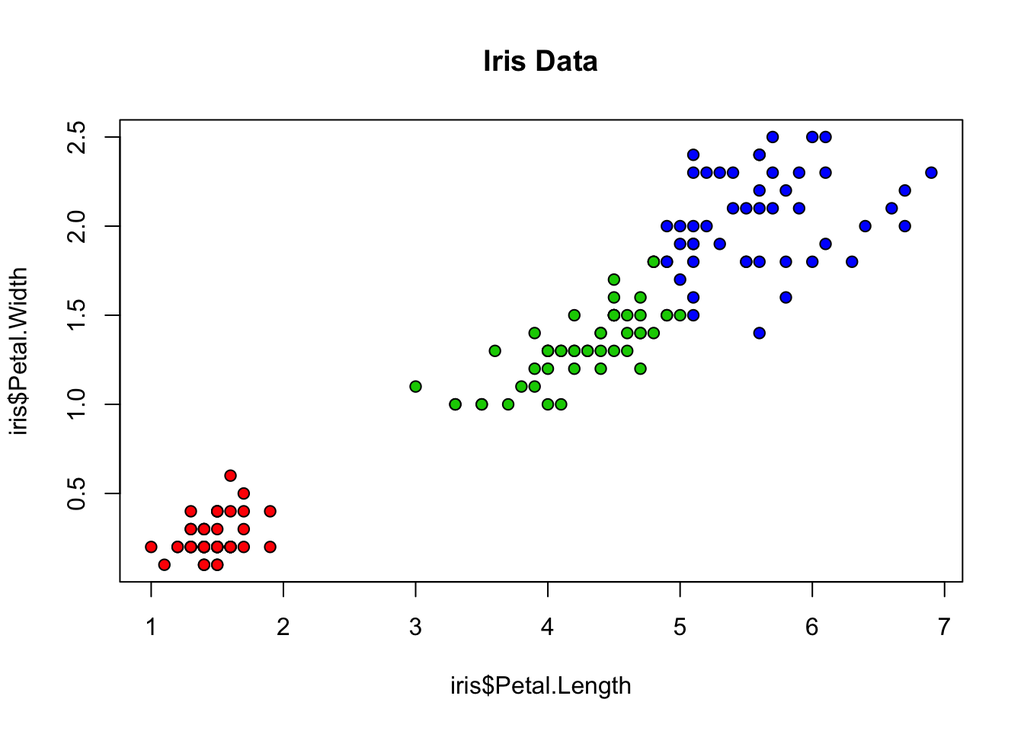

```r
cluster <- as.factor(irisCluster$cluster)
plot(iris$Petal.Length, iris$Petal.Width,pch=21, bg=c("red","green3","blue")[unclass(cluster)], main="Iris Data")
```

You can compare it with the plot of the original data.

## Using RandomForest for classification

```r
library(randomForest)
model.rf <- randomForest(Species ~ . , data=trainset)
model.rf
```

```
##
## Call:
##  randomForest(formula = Species ~ ., data = trainset)
##                Type of random forest: classification
##                      Number of trees: 500
## No. of variables tried at each split: 2
##
##         OOB estimate of  error rate: 1.77%
## Confusion matrix:
##            setosa versicolor virginica class.error
## setosa         37          0         0  0.00000000
## versicolor      0         39         0  0.00000000
## virginica       0          2        35  0.05405405
```

```r
pred.rf <- predict(model.rf,testset[,-5])
tab <- table(pred = pred.rf, true = testset[,5])
tab
```

```
##             true
## pred         setosa versicolor virginica
##   setosa         13          0         0
##   versicolor      0          8         1
##   virginica       0          3        12
```

tuning Random Forest

```
## mtry = 2  OOB error = 4.42%
## Searching left ...
## Searching right ...
## mtry = 3     OOB error = 0%
## 1 0.01
## mtry = 4     OOB error = 0.88%
## -Inf 0.01
```

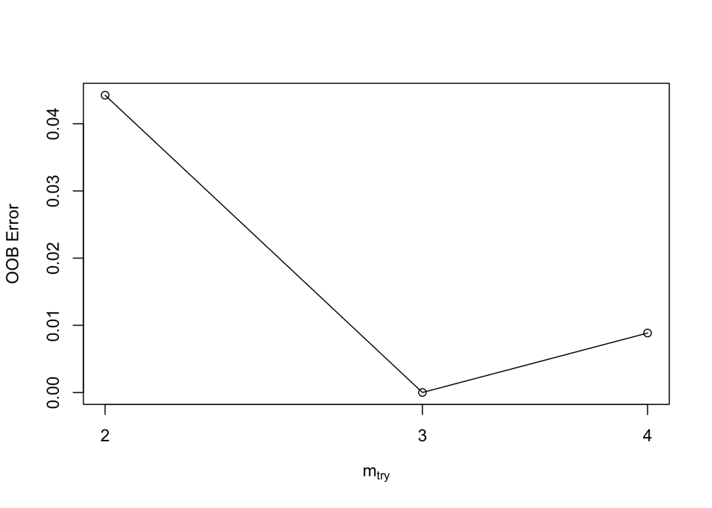

```
##       mtry    OOBError
## 2.OOB    2 0.044247788
## 3.OOB    3 0.000000000
## 4.OOB    4 0.008849558
```

```r
tuneRF(trainset[,-5],trainset[,5],ntreeTry=100,
     stepFactor=1.5,improve=0.01, trace=TRUE, plot=TRUE, dobest=FALSE)
```

```r
model.rf.tune <-randomForest(Species ~.,data=trainset, mtry=2, ntree=1000,
     keep.forest=TRUE, importance=TRUE,test=testset)
model.rf.tune
```

```
##
## Call:
##  randomForest(formula = Species ~ ., data = trainset, mtry = 2,      ntree = 1000, keep.forest = TRUE, importance = TRUE, test = testset)
##                Type of random forest: classification
##                      Number of trees: 1000
## No. of variables tried at each split: 2
##
##         OOB estimate of  error rate: 0.88%
## Confusion matrix:
##            setosa versicolor virginica class.error
## setosa         37          0         0  0.00000000
## versicolor      0         39         0  0.00000000
## virginica       0          1        36  0.02702703
```

```r
pred.rf.tune <- predict(model.rf.tune,testset[,-5])
tab <- table(pred = pred.rf.tune, true = testset[,5])
tab
```

```
##             true
## pred         setosa versicolor virginica
##   setosa         13          0         0
##   versicolor      0          8         1
##   virginica       0          3        12
```

## Neural Network

```r
library(caret)
library(nnet)
model <- train(Species ~ ., trainset, method='nnet', trace = FALSE) # train
# we also add parameter 'preProc = c("center", "scale"))' at train() for centering and scaling the data
model
```

```
## Neural Network
##
## 113 samples
##   4 predictor
##   3 classes: 'setosa', 'versicolor', 'virginica'
##
## No pre-processing
## Resampling: Bootstrapped (25 reps)
## Summary of sample sizes: 113, 113, 113, 113, 113, 113, ...
## Resampling results across tuning parameters:
##
##   size  decay  Accuracy   Kappa      Accuracy SD  Kappa SD
##   1     0e+00  0.7735762  0.6751539  0.25591825   0.36419598
##   1     1e-04  0.7946944  0.7140771  0.30804379   0.42165891
##   1     1e-01  0.9716020  0.9567527  0.02490820   0.03815314
##   3     0e+00  0.8905111  0.8367385  0.14953515   0.22105345
##   3     1e-04  0.9764325  0.9639294  0.01952852   0.03009513
##   3     1e-01  0.9873686  0.9805940  0.01568209   0.02406913
##   5     0e+00  0.9424474  0.9135321  0.10627737   0.15824228
##   5     1e-04  0.9805708  0.9703119  0.01537177   0.02344884
##   5     1e-01  0.9873686  0.9805940  0.01568209   0.02406913
##
## Accuracy was used to select the optimal model using  the largest value.
## The final values used for the model were size = 3 and decay = 0.1.
```

```r
prediction <- predict(model, testset[-5])                           # predict
tab <- table(prediction, testset[,5])                                  # compare
tab
```

```
##
## prediction   setosa versicolor virginica
##   setosa         13          0         0
##   versicolor      0          8         0
##   virginica       0          3        13
```

Tuning the nnet for parameter size. Train function from caret package is a good starting point for this

```r
my.grid <- expand.grid(.decay = c(0.5, 0.1), .size = c(2,3,4,5))
model.nnet.tune <- train(Species ~ ., trainset, method='nnet',maxit = 1000, tuneGrid = my.grid, trace = F)
model.nnet.tune
```

```
## Neural Network
##
## 113 samples
##   4 predictor
##   3 classes: 'setosa', 'versicolor', 'virginica'
##
## No pre-processing
## Resampling: Bootstrapped (25 reps)
## Summary of sample sizes: 113, 113, 113, 113, 113, 113, ...
## Resampling results across tuning parameters:
##
##   decay  size  Accuracy   Kappa      Accuracy SD  Kappa SD
##   0.1    2     0.9785686  0.9675402  0.01825667   0.02759516
##   0.1    3     0.9785686  0.9675540  0.01825667   0.02759317
##   0.1    4     0.9795210  0.9689985  0.01874201   0.02832866
##   0.1    5     0.9795210  0.9689985  0.01874201   0.02832866
##   0.5    2     0.9795535  0.9689581  0.01866261   0.02829276
##   0.5    3     0.9787757  0.9678022  0.01665941   0.02521709
##   0.5    4     0.9795535  0.9689868  0.01721074   0.02605129
##   0.5    5     0.9787024  0.9677062  0.01667527   0.02523743
##
## Accuracy was used to select the optimal model using  the largest value.
## The final values used for the model were size = 2 and decay = 0.5.
```

```r
prediction <- predict(model.nnet.tune, testset[-5])                    # predict
tab <- table(prediction, testset[,5])                                  # compare
tab
```

```
##
## prediction   setosa versicolor virginica
##   setosa         13          0         0
##   versicolor      0          8         0
##   virginica       0          3        13
```

## Generalised Boosted Models

This is available as the method gbm in caret package

```r
fitControl <- trainControl(method="repeatedcv",
                           number=5,
                           repeats=1,
                           verboseIter=TRUE)
set.seed(25)
model.gbm <- train(Species ~ ., data=iris,
                method="gbm",
                trControl=fitControl,
                verbose=FALSE)
model.gbm
```

```
## Stochastic Gradient Boosting
##
## 150 samples
##   4 predictor
##   3 classes: 'setosa', 'versicolor', 'virginica'
##
## No pre-processing
## Resampling: Cross-Validated (5 fold, repeated 1 times)
## Summary of sample sizes: 120, 120, 120, 120, 120
## Resampling results across tuning parameters:
##
##   interaction.depth  n.trees  Accuracy   Kappa  Accuracy SD  Kappa SD
##   1                   50      0.9533333  0.93   0.05055250   0.07582875
##   1                  100      0.9533333  0.93   0.03800585   0.05700877
##   1                  150      0.9533333  0.93   0.03800585   0.05700877
##   2                   50      0.9400000  0.91   0.04944132   0.07416198
##   2                  100      0.9533333  0.93   0.03800585   0.05700877
##   2                  150      0.9400000  0.91   0.04944132   0.07416198
##   3                   50      0.9666667  0.95   0.02357023   0.03535534
##   3                  100      0.9600000  0.94   0.02788867   0.04183300
##   3                  150      0.9533333  0.93   0.02981424   0.04472136
##
## Tuning parameter 'shrinkage' was held constant at a value of 0.1
##
## Tuning parameter 'n.minobsinnode' was held constant at a value of 10
## Accuracy was used to select the optimal model using  the largest value.
## The final values used for the model were n.trees = 50, interaction.depth
##  = 3, shrinkage = 0.1 and n.minobsinnode = 10.
```

```r
prediction <- predict(model.gbm, testset[-5])
tab <- table(prediction, testset[,5])
tab
```

```
##
## prediction   setosa versicolor virginica
##   setosa         13          0         0
##   versicolor      0         10         0
##   virginica       0          1        13
```